# backward_propagation

## 1. Data preprocessing (lab 1)

### Fetch data

```python
from ucimlrepo import fetch_ucirepo

heart_disease = fetch_ucirepo(id=45)
```

### Pickle & unpickle data

```python
import pickle
from pathlib import Path

pickles_dir = Path.cwd().parents[1] / "data"
pickles_dir.mkdir(exist_ok=True)
pickle_file = pickles_dir / "heart_disease.pkl"

with open(pickle_file, 'wb') as picklefile:
    pickle.dump(heart_disease, picklefile)
```

```python
import pickle
from pathlib import Path

pickle_file = Path.cwd().parents[1] / "data" / "heart_disease.pkl"

with open(pickle_file, 'rb') as picklefile:
    heart_disease = pickle.load(picklefile)
```

```python
print(heart_disease)
```

### Create a feature matrix

```python
import pandas as pd
from sklearn.impute import SimpleImputer
from sklearn.preprocessing import MinMaxScaler, OneHotEncoder

cat_features = ["sex", "cp", "fbs", "restecg", "exang", "slope", "ca", "thal"]
num_features = ["age", "trestbps", "chol", "thalach", "oldpeak"]

original_df = heart_disease.data.features

# Prepare categorical data
imputer = SimpleImputer(strategy="most_frequent")
original_df.loc[:, cat_features] = imputer.fit_transform(original_df[cat_features])

encoder = OneHotEncoder(categories="auto", sparse_output=False)
encoded_cat_data = encoder.fit_transform(original_df[cat_features])
encoded_features = encoder.get_feature_names_out(cat_features)
original_df[encoded_features] = pd.DataFrame(encoded_cat_data, columns=encoded_features)

# Prepare numerical data
scaler = MinMaxScaler()
scaled_num_data = scaler.fit_transform(original_df[num_features])
original_df[num_features] = pd.DataFrame(scaled_num_data, columns=num_features)

# Convert DataFrame to feature matrix
original_df = original_df.drop(columns=cat_features)
X = original_df.to_numpy()
```

### Create a target vector (convert values to {0,1} for binary classification)

```python
import numpy as np

y = heart_disease.data.targets.to_numpy()
y_binary = np.where(y >= 1, 1, 0)
```

### Verify matrix/vector dimensions

```python
print(f"Feature matrix shape: {X.shape}")
print(f"Target vector shape: {y_binary.shape}")
```

```
Feature matrix shape: (303, 28)
Target vector shape: (303, 1)
```

### Split dataset to test and train subsets

```python
from sklearn.model_selection import train_test_split

X_train, X_test, y_train, y_test = train_test_split(X, y_binary, test_size=0.2, random_state=42)
X_train = X_train.T
X_test = X_test.T
```

```python
print(f"X_train shape: {X_train.shape}")
print(f"X_test shape: {X_test.shape}")
print(f"y_train shape: {y_train.shape}")
print(f"y_test shape: {y_test.shape}")
```

```
X_train shape: (28, 242)
X_test shape: (28, 61)
y_train shape: (242, 1)
y_test shape: (61, 1)
```

## 2. Model

### Layer definition

```python
from collections.abc import Callable


class Layer:
    def __init__(self, input_size: int, output_size: int, std_dev: float):
        self.weights = np.random.randn(output_size, input_size) * std_dev
        self.bias = np.zeros((output_size, 1))

    def forward(self, a_prev: np.ndarray, f_activ: Callable) -> np.ndarray:
        self.cache_a_prev = a_prev
        self.cache_z = self.weights @ a_prev + self.bias
        return f_activ(self.cache_z)

    def backward(self, delta_next: np.ndarray, derivative_f_activ: Callable):
        self.delta = delta_next * derivative_f_activ(self.cache_z)
        return self.weights.T @ self.delta
```

### Network definition

```python
from sklearn.metrics import accuracy_score, f1_score, recall_score


def sigmoid(z: np.ndarray) -> np.ndarray:
    return 1 / (1 + np.exp(-z))

def sigmoid_derivative(z: np.ndarray) -> np.ndarray:
    s = sigmoid(z)
    return s * (1 - s)


class Network:
    def __init__(
        self,
        layers_dims: list[tuple[int, int]],
        learning_rate: float,
        std_dev: float,
        f_activ: Callable = sigmoid,
        f_activ_derivative: Callable = sigmoid_derivative
    ):
        self.layers: list[Layer] = []
        self.learning_rate = learning_rate
        self.f_activ = f_activ
        self.f_activ_derivative = f_activ_derivative
        for input_s, output_s in layers_dims:
            self.layers.append(Layer(input_s, output_s, std_dev))

    def pass_forward(self, X: np.ndarray):
        a = self.layers[0].forward(X, self.f_activ)
        for i in range(1, len(self.layers)):
            a = self.layers[i].forward(a, self.f_activ)
        return a

    def pass_backward(self, delta):
        self.layers[-1].delta = delta
        delta = self.layers[-1].weights.T @ delta
        for layer in self.layers[::-1][1:]:
            delta = layer.backward(delta, self.f_activ_derivative)

    def calculate_error_delta(self, last_layer: Layer, y_pred, y_true):
        d_cost_d_a = (y_pred - y_true) / (y_pred * (1 - y_pred))
        delta = d_cost_d_a * self.f_activ_derivative(last_layer.cache_z)
        return delta

    def calculate_cost(self, y_pred, y_true):
        vector = (-y_true * np.log(y_pred)) - ((1 - y_true) * np.log(1 - y_pred))
        return np.sum(vector) / y_true.shape[1]

    def update_weights_biases(self):
        for layer in self.layers[::-1][:-1]:
            layer.weights -= self.learning_rate * (layer.delta @ layer.cache_a_prev.T)
            layer.bias -= self.learning_rate * np.sum(layer.delta, axis=1, keepdims=True)

    def run_epoch(self, X_train, y_train, X_test, y_test) -> dict[str, float]:
        y_train_pred = self.pass_forward(X_train)
        delta = self.calculate_error_delta(self.layers[-1], y_train_pred, y_train.T)
        self.pass_backward(delta)
        self.update_weights_biases()

        y_test_pred = self.pass_forward(X_test)
        y_test_pred_binary = (y_test_pred >= 0.5).astype(int).T

        train_cost = self.calculate_cost(y_true=y_train.T, y_pred=y_train_pred)
        results = {
            "recall": recall_score(y_true=y_test, y_pred=y_test_pred_binary),
            "f1": f1_score(y_true=y_test, y_pred=y_test_pred_binary),
            "accuracy": accuracy_score(y_true=y_test, y_pred=y_test_pred_binary),
            "cost": train_cost
        }
        return results
```

```python
import matplotlib.pyplot as plt


def plot_metrics(results: dict[int, np.float64], epochs: int):
    x = list(results.keys())
    recall = [results[i]['recall'] for i in x]
    f1 = [results[i]['f1'] for i in x]
    accuracy = [results[i]['accuracy'] for i in x]

    plt.figure(figsize=(8, 6))
    plt.plot(x, recall, linestyle='-', color='r', label='Recall')
    plt.plot(x, f1, linestyle='-', color='g', label='F1 Score')
    plt.plot(x, accuracy, linestyle='-', color='b', label='Accuracy')

    plt.xlabel('Epoch')
    plt.ylabel('Metric score')
    plt.title('Plot of metric scores')

    plt.xlim(0, epochs)

    plt.legend()

    plt.grid(True)
    plt.show()


def plot_cost(results: dict[int, np.float64], epochs: int):
    x = list(results.keys())
    cost = [results[i]['cost'] for i in x]

    plt.figure(figsize=(8, 6))
    plt.plot(x, cost, linestyle='-', color='r', label='Cost')

    plt.xlabel('Epoch')
    plt.ylabel('Cost function value')
    plt.title('Plot of cost value over time (epochs)')

    plt.xlim(0, epochs)

    plt.legend()

    plt.grid(True)
    plt.show()
```

## 3. Analysis

### Hidden layer dimensionality

```
Model with the following dimensions: [(28, 8), (8, 1)]
```

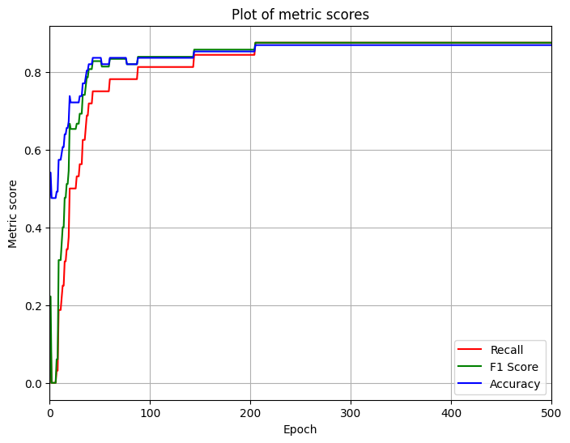

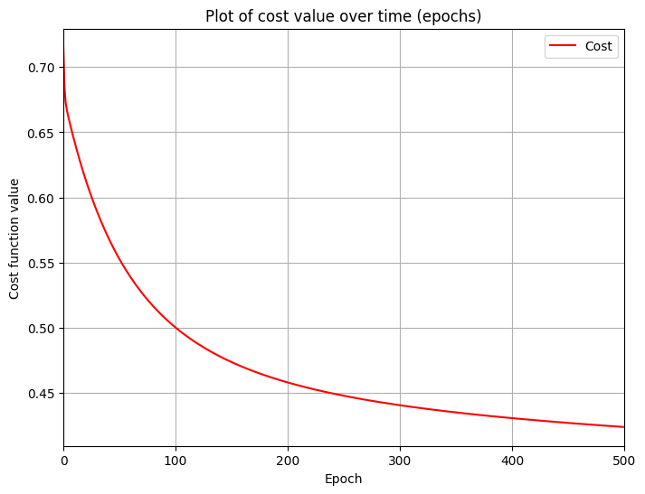

```
Model with the following dimensions: [(28, 16), (16, 1)]
```

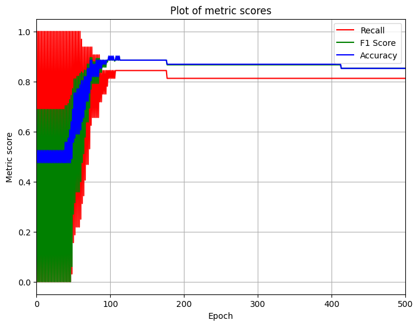

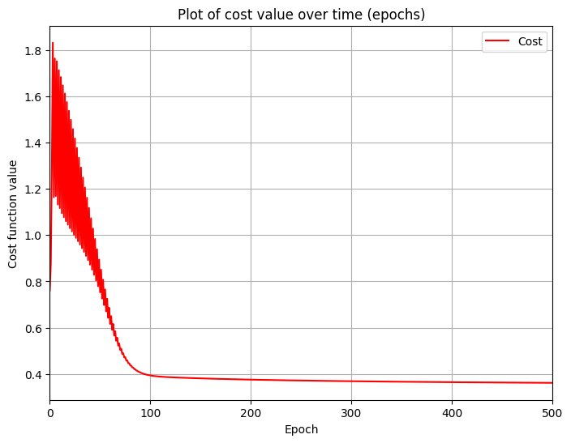

```
Model with the following dimensions: [(28, 45), (45, 1)]
```

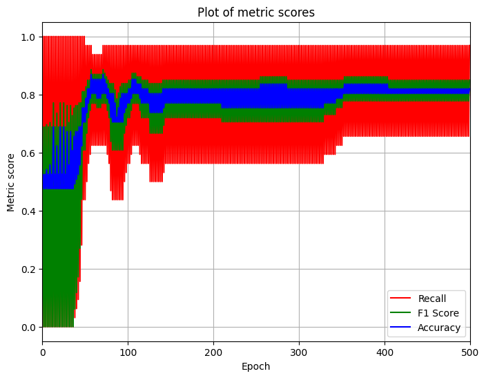

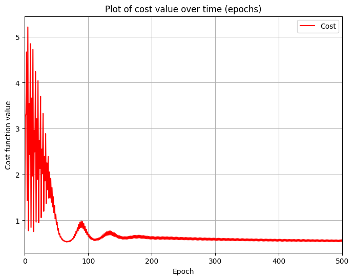

```python
dimensions_options = [
    [(X_train.shape[0], 8), (8, 1)],
    [(X_train.shape[0], 16), (16, 1)],
    [(X_train.shape[0], 45), (45, 1)],
]


def run(model: Network, epoch_limit: int) -> dict[int, dict[str, np.float64]]:
    results = {}
    for i in range(epoch_limit):
        results[i] = model.run_epoch(X_train, y_train, X_test, y_test)
    return results


for dims in dimensions_options:
    model = Network(
        layers_dims=dims,
        learning_rate=0.01,
        std_dev=0.25
    )
    results = run(model, 500)
    print(f"Model with the following dimensions: {dims}")
    plot_metrics(results, 500)
    plot_cost(results, 500)
```

#### Analysis

The graphs show that the dimensionality of the hidden layer does indeed have a strong influence on the performance of the network. We performed 3 tests: with a small dimension (8 neurons), medium (16 neurons) and large (45 dimensions). [The input data has 28 features.]

### Learning rate

```
Model with the following learning rate: 0.001
```

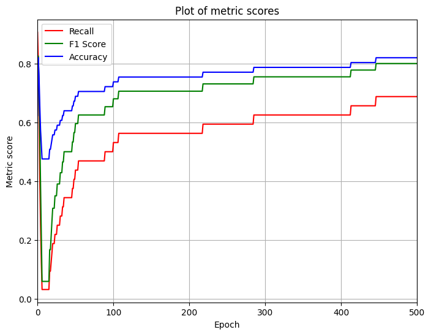

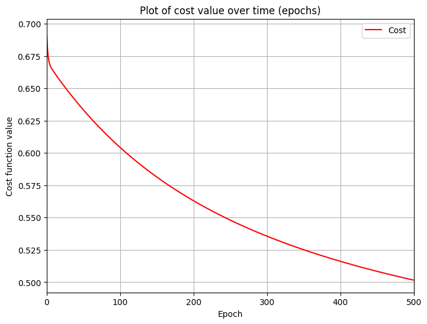

```
Model with the following learning rate: 0.005
```

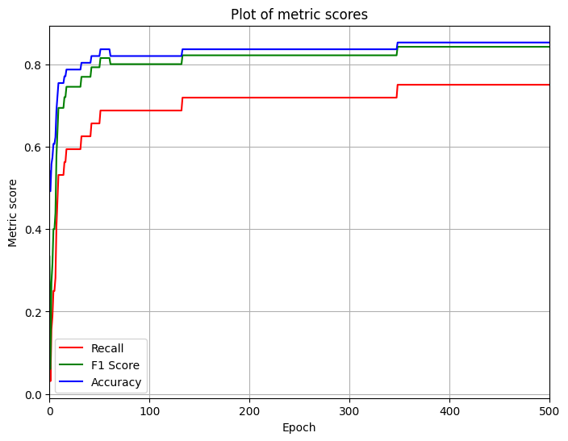

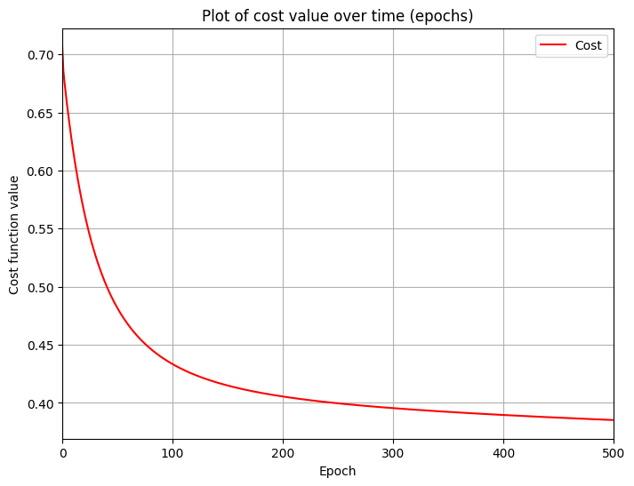

```
Model with the following learning rate: 0.01
```

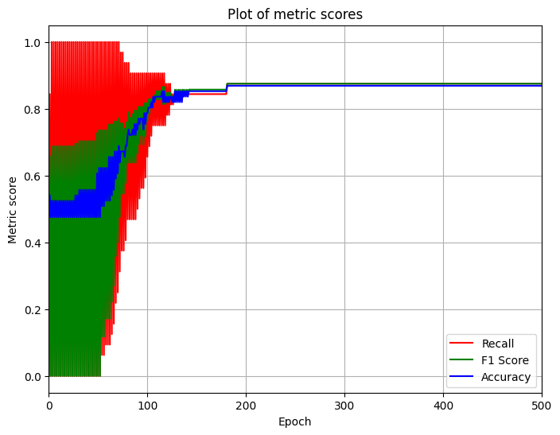

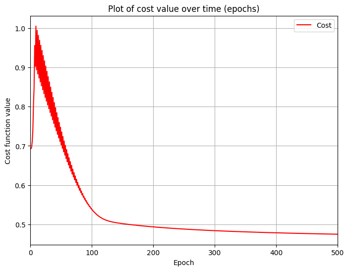

```
Model with the following learning rate: 0.05
```

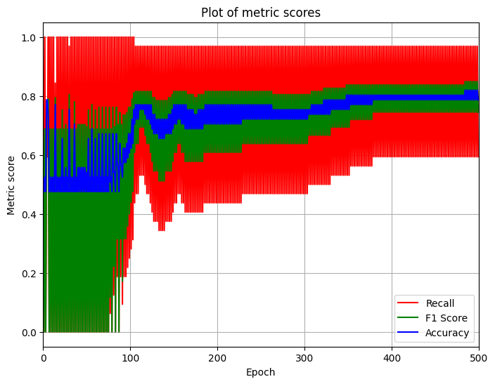

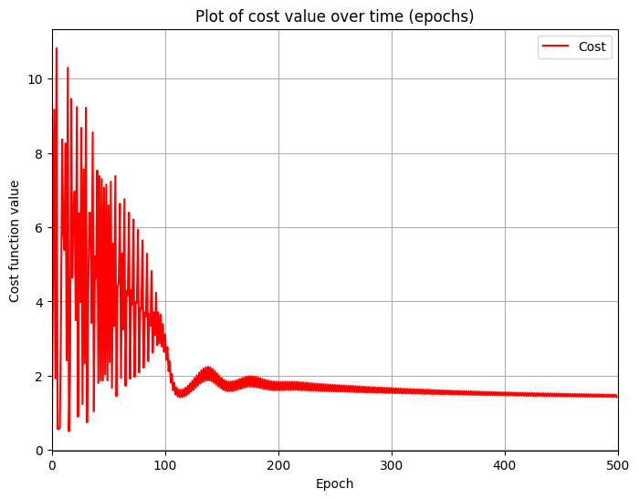

```python
learning_rates = [
    0.001, 0.005, 0.01, 0.05
]


def run(model: Network, epoch_limit: int) -> dict[int, dict[str, np.float64]]:
    results = {}
    for i in range(epoch_limit):
        results[i] = model.run_epoch(X_train, y_train, X_test, y_test)
    return results


for rate in learning_rates:
    model = Network(
        layers_dims=[(X_train.shape[0], 14), (14, 1)],
        learning_rate=rate,
        std_dev=0.25
    )
    results = run(model, 500)
    print(f"Model with the following learning rate: {rate}")
    plot_metrics(results, 500)
    plot_cost(results, 500)
```

#### Analysis

In this case we can observe the influence of the learning rate on the model performance. 4 tests were performed with the following values

- 0.001: this value was definitely too low for this model. Small improvements in the metrics were visible, but after many epochs. The cost curve was slowly descending.
- 0.005: In this scenario the model performed much better - metric scores were higher and cost was eventually lower, but the learning process could still be a bit faster - after many epochs small improvements were still noticeable.
- 0.01: With this learning rate model the final metrics were reached very quickly (<200 epochs) and the values were great. The cost was slightly higher than in the previous experiment. Probably some value from the range: [0.005, 0.01] would be best.
- 0.05: Here the learning rate was definitely too high, the model was unstable, the cost was very high compared to the other test cases and in general no clear metrics were achieved.

### Std dev

```
Model with the following std dev: 0.01
```

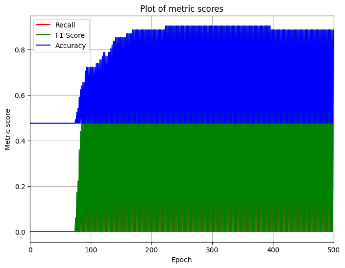

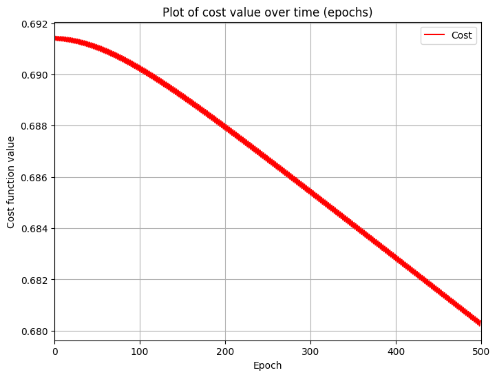

```
Model with the following std dev: 0.25
```

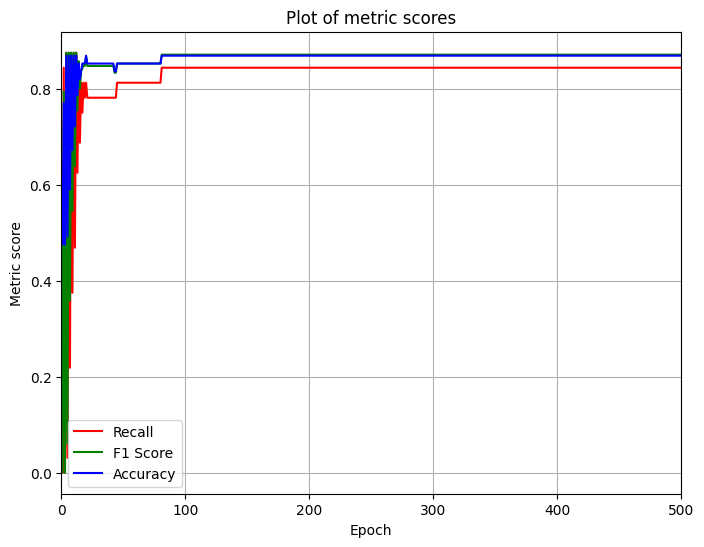

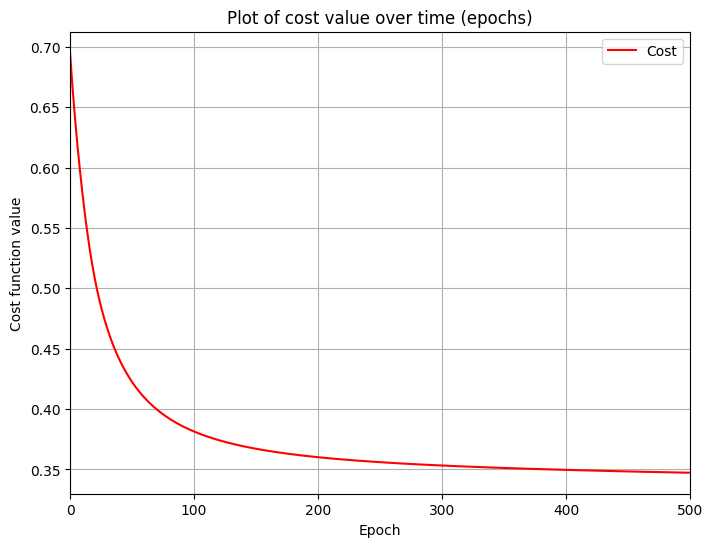

```
Model with the following std dev: 0.5
```

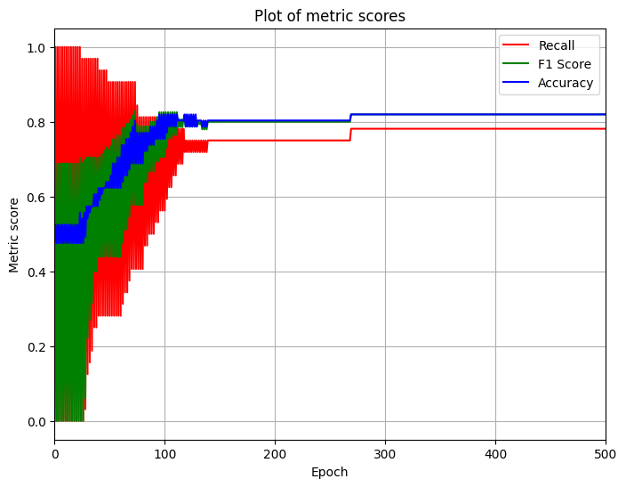

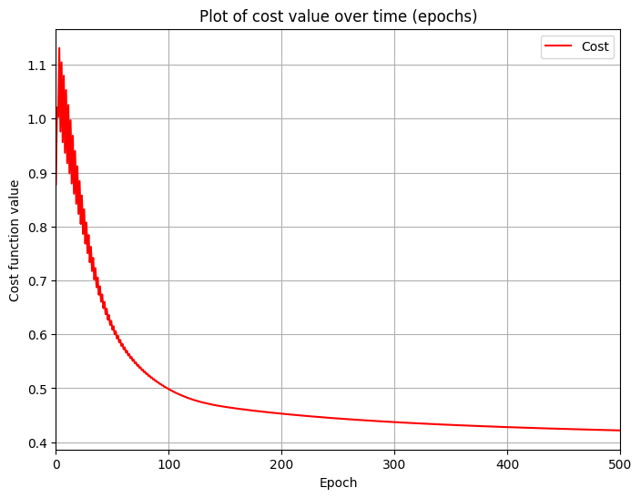

```python
std_devs = [
    0.01, 0.25, 0.5
]


def run(model: Network, epoch_limit: int) -> dict[int, dict[str, np.float64]]:
    results = {}
    for i in range(epoch_limit):
        results[i] = model.run_epoch(X_train, y_train, X_test, y_test)
    return results


for std_dev in std_devs:
    model = Network(
        layers_dims=[(X_train.shape[0], 14), (14, 1)],
        learning_rate=0.0075,
        std_dev=std_dev
    )
    results = run(model, 500)
    print(f"Model with the following std dev: {std_dev}")
    plot_metrics(results, 500)
    plot_cost(results, 500)
```

#### Analysis

3 values were tested:

- 0.01: with such a small std dev, the weight values were initially clustered closer to 0. This can cause a vanishing gradient problem. The network was indeed stuck during training because the gradients calculated during backpropagation were too small, so the weights were not updated properly. Metric values were unstable, cost was relatively high.
- 0.25: In this case the model performed really well, the learning phase was even too short, but the metric scores obtained were high and the cost was really low. This is because the weights were more distributed and could be updated more effectively.
- 0.5: With this std dev value the model also performed very well. The weights were initially more spread out because of the larger std dev. That's why the learning phase took longer, but in the end the metric values were high, only slightly lower than in (2).

### Data normalization

```
Model with no data normalization
```

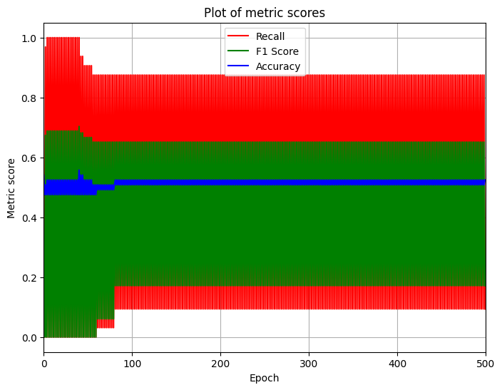

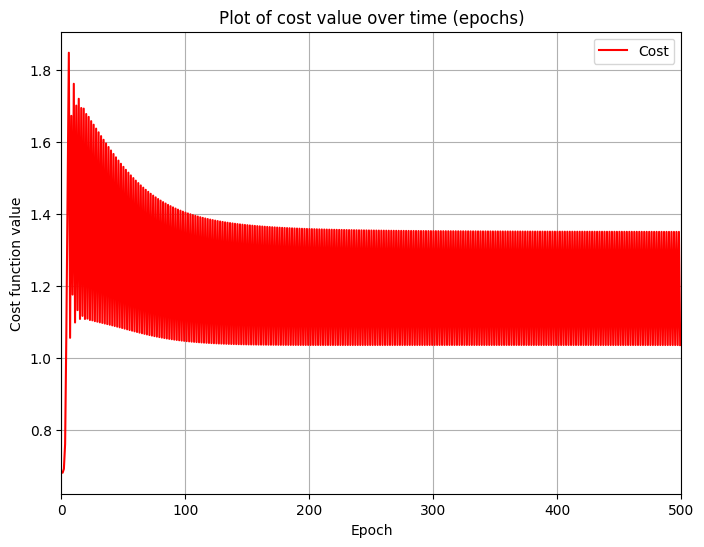

```
Model with data normalization
```

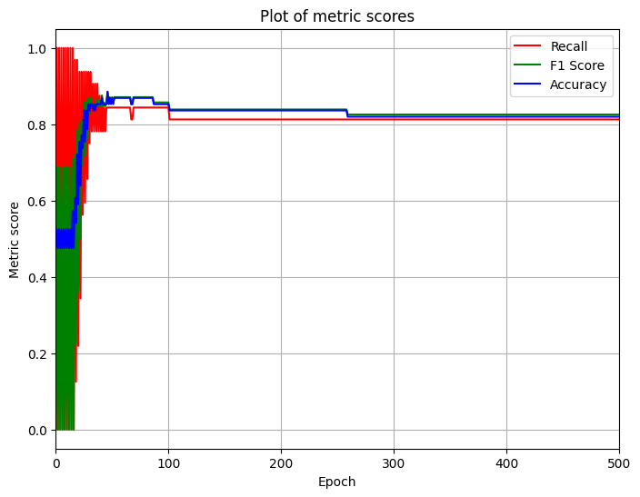

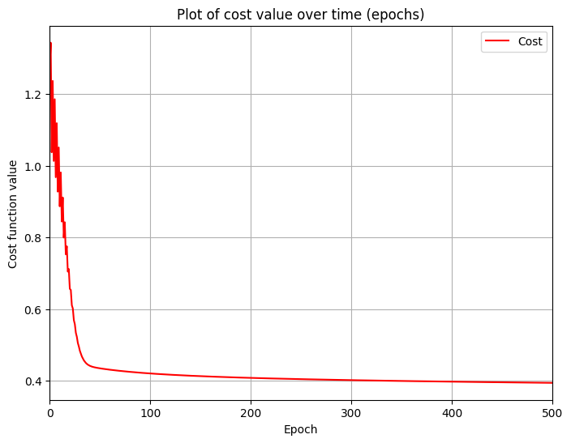

```python
import pandas as pd
from sklearn.impute import SimpleImputer
from sklearn.model_selection import train_test_split
from sklearn.preprocessing import MinMaxScaler, OneHotEncoder
from ucimlrepo import fetch_ucirepo

heart_disease = fetch_ucirepo(id=45)

cat_features = ["sex", "cp", "fbs", "restecg", "exang", "slope", "ca", "thal"]
num_features = ["age", "trestbps", "chol", "thalach", "oldpeak"]

original_df = heart_disease.data.features

# Prepare categorical data
imputer = SimpleImputer(strategy="most_frequent")
original_df.loc[:, cat_features] = imputer.fit_transform(original_df[cat_features])

encoder = OneHotEncoder(categories="auto", sparse_output=False)
encoded_cat_data = encoder.fit_transform(original_df[cat_features])
encoded_features = encoder.get_feature_names_out(cat_features)
original_df[encoded_features] = pd.DataFrame(encoded_cat_data, columns=encoded_features)

# Convert DataFrame to feature matrix
original_df = original_df.drop(columns=cat_features)
X = original_df.to_numpy()

y = heart_disease.data.targets.to_numpy()
y_binary = np.where(y >= 1, 1, 0)

X_train, X_test, y_train, y_test = train_test_split(X, y_binary, test_size=0.2, random_state=42)
X_train = X_train.T
X_test = X_test.T


def run(model: Network, epoch_limit: int) -> dict[int, dict[str, np.float64]]:
    results = {}
    for i in range(epoch_limit):
        results[i] = model.run_epoch(X_train, y_train, X_test, y_test)
    return results


model = Network(
    layers_dims=[(X_train.shape[0], 14), (14, 1)],
    learning_rate=0.0075,
    std_dev=0.35
)
results = run(model, 500)
print("Model with no data normalization")
plot_metrics(results, 500)
plot_cost(results, 500)


heart_disease = fetch_ucirepo(id=45)

cat_features = ["sex", "cp", "fbs", "restecg", "exang", "slope", "ca", "thal"]
num_features = ["age", "trestbps", "chol", "thalach", "oldpeak"]

original_df = heart_disease.data.features

# Prepare categorical data
imputer = SimpleImputer(strategy="most_frequent")
original_df.loc[:, cat_features] = imputer.fit_transform(original_df[cat_features])

encoder = OneHotEncoder(categories="auto", sparse_output=False)
encoded_cat_data = encoder.fit_transform(original_df[cat_features])
encoded_features = encoder.get_feature_names_out(cat_features)
original_df[encoded_features] = pd.DataFrame(encoded_cat_data, columns=encoded_features)

# Prepare numerical data
scaler = MinMaxScaler()
scaled_num_data = scaler.fit_transform(original_df[num_features])
original_df[num_features] = pd.DataFrame(scaled_num_data, columns=num_features)

# Convert DataFrame to feature matrix
original_df = original_df.drop(columns=cat_features)
X = original_df.to_numpy()

y = heart_disease.data.targets.to_numpy()
y_binary = np.where(y >= 1, 1, 0)

X_train, X_test, y_train, y_test = train_test_split(X, y_binary, test_size=0.2, random_state=42)
X_train = X_train.T
X_test = X_test.T

def run(model: Network, epoch_limit: int) -> dict[int, dict[str, np.float64]]:
    results = {}
    for i in range(epoch_limit):
        results[i] = model.run_epoch(X_train, y_train, X_test, y_test)
    return results

model = Network(
    layers_dims=[(X_train.shape[0], 14), (14, 1)],
    learning_rate=0.0075,
    std_dev=0.35
)
results = run(model, 500)
print("Model with data normalization")
plot_metrics(results, 500)
plot_cost(results, 500)
```

#### Analysis

The comparison is self-explanatory. Data standardisation is a crucial step in building a neural network. Without it, the weights will not be adjusted correctly because some features have a much greater impact, not because they are more important, but because their domains are different. Without this standardisation, the model is unstable and clearly does not learn.

### Number of layers

```
Model with the following dimensions: [(28, 14), (14, 1)]
```

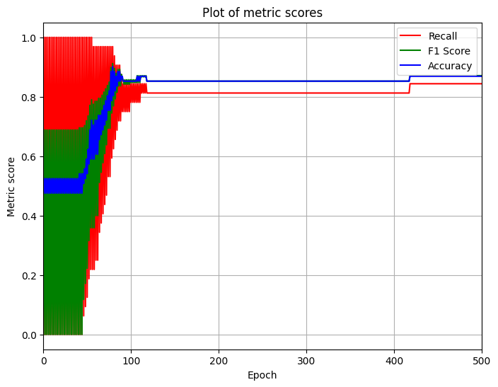

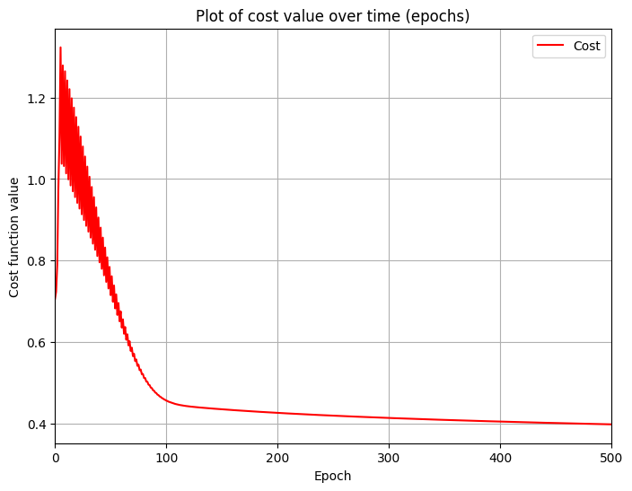

```
Model with the following dimensions: [(28, 16), (16, 8), (8, 1)]
```

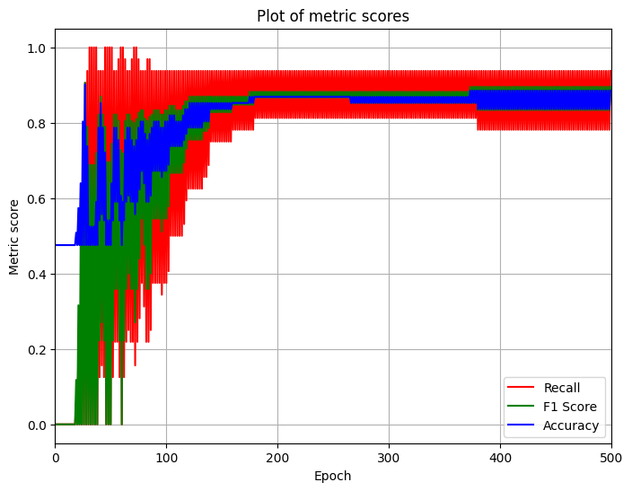

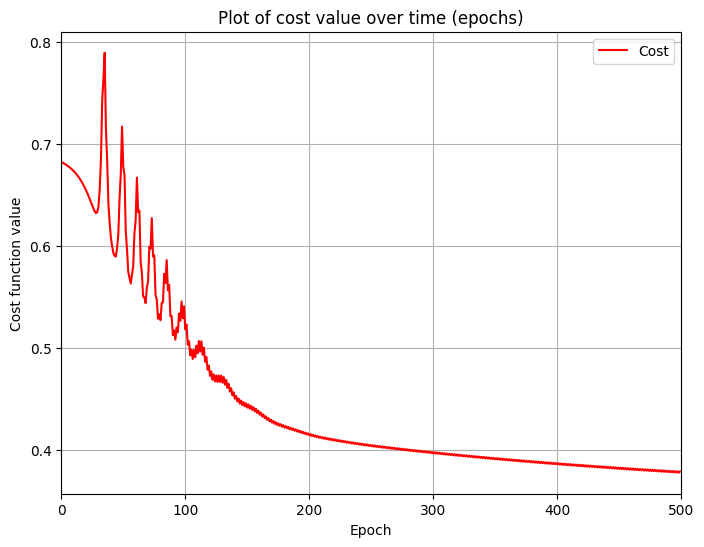

```
Model with the following dimensions: [(28, 32), (32, 16), (16, 8), (8, 1)]
```

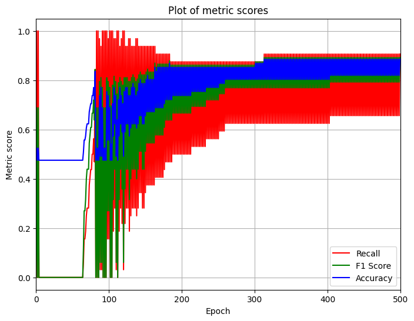

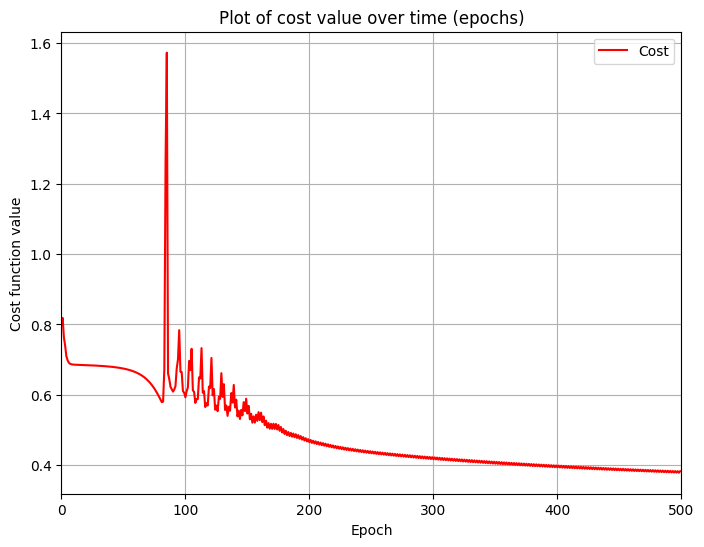

```python
dimensions_options = [
    [(X_train.shape[0], 14), (14, 1)],
    [(X_train.shape[0], 16), (16, 8), (8, 1)],
    [(X_train.shape[0], 32), (32, 16), (16, 8), (8, 1)]
]


def run(model: Network, epoch_limit: int) -> dict[int, dict[str, np.float64]]:
    results = {}
    for i in range(epoch_limit):
        results[i] = model.run_epoch(X_train, y_train, X_test, y_test)
    return results


for dims in dimensions_options:
    model = Network(
        layers_dims=dims,
        learning_rate=0.01,
        std_dev=0.25
    )
    results = run(model, 500)
    print(f"Model with the following dimensions: {dims}")
    plot_metrics(results, 500)
    plot_cost(results, 500)
```

#### Analysis

The number of layers also has a significant impact on network performance. In this particular example, any network with more than 1 hidden layer is overkill. With such a small dataset, 1 hidden layer is perfectly sufficient - the metrics are high and stable, the cost is relatively low. With 2 hidden layers, the metrics are also high, but less stable, and the network seems to be "looking for more improvement" as there are more possible adjustments. With 3 hidden layers this is even more visible.